# Grupo México, S.A.B. de C.V.

Acción Serie B — GMEXICOB

[figure not shown]

**INTEGRANTES**

Gibrán Chávez  
Carlos Nieves  
Pablo Tafolla  
Carlos Romo

**Materia:** Análisis del Riesgo  
**Docente:** María del Rosario Ruiz Hernández  
**Fecha:** 24 de septiembre de 2026

# 1 Introducción

En esta segunda parte analizamos los cambios históricos en el precio y los rendimientos de Grupo México, con el propósito de relacionar los movimientos de su acción con acontecimientos económicos, políticos y empresariales. A partir de las gráficas, identificamos periodos de crecimiento, caídas pronunciadas y recuperación, y examinamos qué información pudo modificar las expectativas de los inversionistas en cada momento.

También estimamos el máximo drawdown y comparamos el rendimiento anual de GMEXICOB con el crecimiento del PIB de México. Esta comparación nos permite discutir hasta qué punto la acción acompaña al ciclo económico nacional y por qué, en determinados años, presenta un comportamiento diferente. Finalmente, revisamos los acontecimientos del último año comprendido en la serie y reflexionamos sobre el riesgo que implica invertir en un activo expuesto tanto a las decisiones de la empresa como a cambios del entorno internacional.

# 2 Exploración de la serie histórica

```r
library(quantmod); library(moments); library(WDI); library(ggplot2); library(PerformanceAnalytics)
```

## 2.1 Gráfica de precio y rendimientos históricos

Trabajamos con la serie de precios de cierre ajustados de GMEXICOB.MX obtenida de Yahoo Finance, correspondiente al periodo del 3 de enero de 2000 al 30 de junio de 2026. Este es el intervalo utilizado en nuestro análisis, aunque no representa toda la historia bursátil del grupo, ya que las acciones de Grupo México cotizaban en la Bolsa Mexicana de Valores desde antes del año 2000. Sin embargo, en Yahoo Finance únicamente existe registro de la serie a partir del 3 de enero de 2000, por lo que esa es la primera observación disponible y el punto de inicio de nuestro estudio. Por ello, las conclusiones y las medidas de riesgo que presentamos se refieren exclusivamente a esta muestra.

Utilizamos el precio ajustado porque incorpora los ajustes por dividendos y desdoblamientos de acciones, lo que permite comparar las observaciones de distintos momentos con mayor consistencia. En consecuencia, los valores históricos mostrados no deben interpretarse como las cotizaciones nominales exactas que se observaron en cada fecha, y sus variaciones incorporan el tratamiento de estas distribuciones por parte del proveedor ([Yahoo, s. f.](https://help.yahoo.com/kb/SLN28256.html)).

Calculamos los rendimientos simples diarios mediante la expresión

$$R_t=\frac{P_t}{P_{t-1}}-1$$

y los rendimientos logarítmicos mediante

$$r_t=\ln\left(\frac{P_t}{P_{t-1}}\right).$$

En ambas fórmulas, $P_t$ representa el precio ajustado del día y $P_{t-1}$ el de la sesión anterior. El rendimiento simple expresa directamente la variación proporcional, mientras que el logarítmico facilita la acumulación de rendimientos mediante sumas. Sus valores son muy parecidos cuando los movimientos diarios son pequeños, aunque la diferencia aumenta durante las variaciones más pronunciadas. En las gráficas, un rendimiento de 0.10 equivale a 10%, no a 0.10%.

Ambas medidas se relacionan de forma exacta mediante

$$r_t=\ln(1+R_t), \qquad R_t=e^{r_t}-1,$$

y la propiedad de acumulación del rendimiento logarítmico se expresa como

$$\sum_{t=1}^{T} r_t=\ln\left(\frac{P_T}{P_0}\right), \qquad
\prod_{t=1}^{T}(1+R_t)=\frac{P_T}{P_0}.$$

Es decir, los rendimientos logarítmicos se suman a lo largo del tiempo, mientras que los simples deben capitalizarse (multiplicarse).

```r
ticker <- 'GMEXICOB.MX'


getSymbols(
  ticker,
  src = 'yahoo',
  from = '2000-01-01',
  to = '2026-07-01'
)
```

```
## [1] "GMEXICOB.MX"
```

```r
price <- Ad(get(ticker))

log_price <- log(price)

head(cbind(price, log_price))
```

```
##            GMEXICOB.MX.Adjusted GMEXICOB.MX.Adjusted.1
## 2000-01-03             1.967803              0.6769175
## 2000-01-04             1.942162              0.6638019
## 2000-01-05             1.959256              0.6725649
## 2000-01-06             2.132319              0.7572101
## 2000-01-07             2.264789              0.8174817
## 2000-01-10             2.290428              0.8287389
```

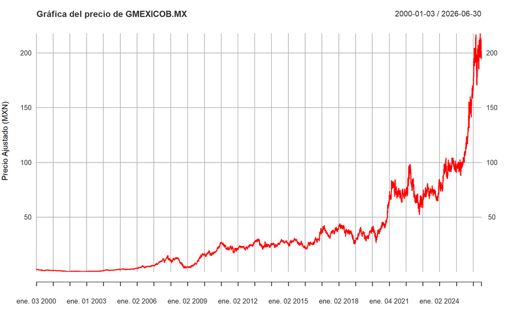

```r
plot(
  price,
  main = paste('Gráfica del precio de', ticker),
  ylab = 'Precio Ajustado (MXN)',
  xlab = '',
  col = 'red'
)
```

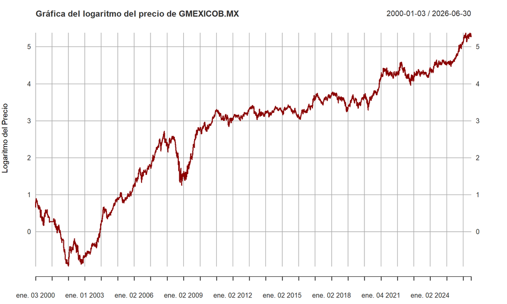

```r
plot(
  log_price,
  main = paste('Gráfica del logaritmo del precio de', ticker),
  ylab = 'Logaritmo del Precio',
  xlab = '',
  col = 'dark red'
)
```

La gráfica del precio muestra una tendencia ascendente de largo plazo, especialmente marcada en el tramo final. Sin embargo, esta escala comprime visualmente las variaciones de los primeros años, puesto que los precios recientes son mucho mayores. La gráfica del logaritmo ayuda a observar mejor las variaciones proporcionales y permite reconocer que las caídas de comienzos de los años dos mil fueron importantes, aunque parezcan pequeñas en la gráfica original. Que el logaritmo sea negativo en ciertos momentos solamente significa que el precio ajustado era inferior a una unidad monetaria, no que la acción tuviera un precio negativo.

```r
simple_rend <- dailyReturn(price, type='arithmetic')

log_rend <- dailyReturn(price, type='log')

head(cbind(simple_rend, log_rend))
```

```
##            daily.returns daily.returns.1
## 2000-01-03   0.000000000      0.00000000
## 2000-01-04  -0.013029949     -0.01311558
## 2000-01-05   0.008801477      0.00876297
## 2000-01-06   0.088330870      0.08464521
## 2000-01-07   0.062125025      0.06027164
## 2000-01-10   0.011320725      0.01125713
```

El valor de 0 en la primera fecha (3 de enero de 2000) no es un rendimiento observado, sino el valor que asigna `dailyReturn` a la primera observación, ya que no existe un precio previo con el cual compararla.

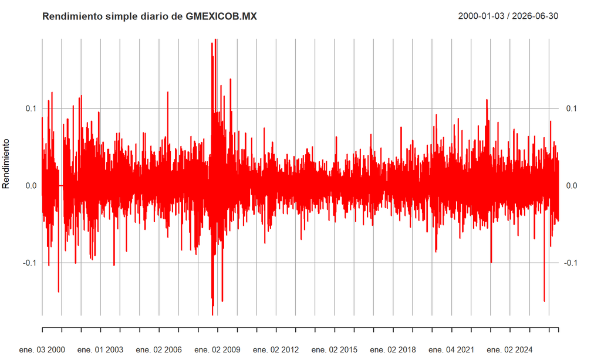

```r
plot(
  simple_rend,
  main = paste('Rendimiento simple diario de', ticker),
  ylab = 'Rendimiento',
  xlab = '',
  col = 'red'
)
```

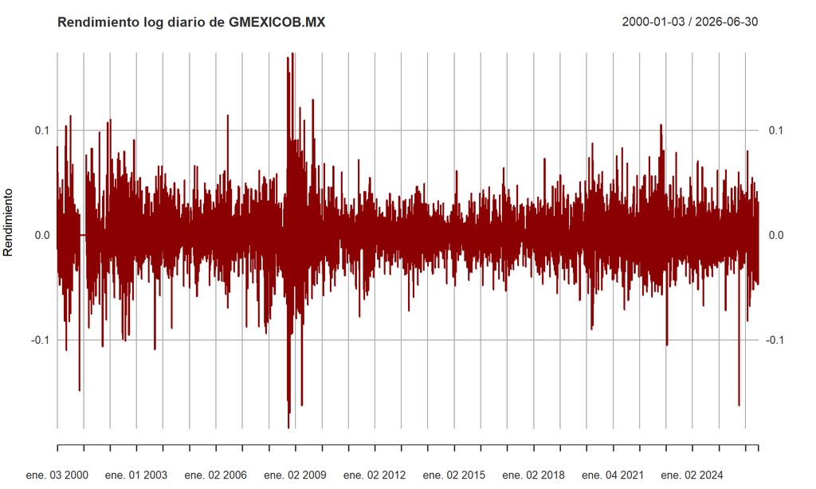

```r
plot(
  log_rend,
  main = paste('Rendimiento log diario de', ticker),
  ylab = 'Rendimiento',
  xlab = '',
  col = 'dark red'
)
```

En las gráficas de rendimientos observamos fluctuaciones alrededor de cero y periodos en los que los movimientos positivos y negativos se vuelven más amplios. Esto resulta especialmente visible durante la crisis de 2008 y en otros episodios de incertidumbre. La concentración de movimientos intensos sugiere que la volatilidad cambia con el tiempo, aunque la inspección visual, por sí sola, no permite establecer una distribución estadística ni cuantificar la probabilidad de una pérdida futura.

Para dar una primera medida numérica de esa dispersión utilizamos la volatilidad, definida como la desviación estándar de los rendimientos diarios, y su versión anualizada, que supone aproximadamente 252 sesiones bursátiles por año:

$$\sigma_{anual}\approx\sigma_{diaria}\sqrt{252}.$$

```r
vol_diaria <- sd(simple_rend)
vol_anual <- vol_diaria * sqrt(252)

c(
  media_diaria = mean(simple_rend),
  volatilidad_diaria = vol_diaria,
  volatilidad_anual = vol_anual
)
```

```
##       media_diaria volatilidad_diaria  volatilidad_anual
##       0.0009778682       0.0242279061       0.3846060854
```

La volatilidad diaria es de aproximadamente 2.42%, equivalente a una volatilidad anualizada cercana a 38.5%. La anualización con $\sqrt{252}$ supone que los rendimientos diarios son independientes y de varianza constante, lo cual es solo una aproximación, puesto que, como se observa en las gráficas, la volatilidad cambia a lo largo del tiempo.

## 2.2 Comportamiento general del activo y periodos relevantes

El comportamiento de GMEXICOB combina una apreciación considerable de largo plazo con pérdidas temporales profundas. Por ello, observar únicamente el precio inicial y final daría una imagen incompleta del riesgo, puesto que durante el recorrido un inversionista habría enfrentado caídas importantes y, en algunos casos, periodos prolongados de recuperación.

Identificamos los siguientes periodos por la magnitud de sus movimientos, los cambios de tendencia y su relevancia para entender la exposición de la empresa.

| Periodo | Movimiento observado | Relevancia para el análisis |
| --- | --- | --- |
| 2000-2002 | Caída máxima de 84.01% dentro del episodio iniciado en enero de 2000. | Es la pérdida más profunda de la muestra y muestra la importancia de combinar riesgo de mercado y situación financiera. |
| 2003-2007 | Recuperación y avance sostenido, con rendimientos anuales de 154.04% en 2003 y 95.01% en 2004. | Permite analizar cómo un entorno favorable para los metales puede mejorar las expectativas de rentabilidad. |
| 2007-2009 | Caída de 76.86% hasta noviembre de 2008, seguida de una recuperación muy pronunciada en 2009. | Muestra la reacción ante una crisis internacional y el cambio posterior de expectativas. |
| 2011 | Descenso de 37.18% desde el máximo previo hasta el mínimo de octubre. | Refleja la sensibilidad del activo a la incertidumbre financiera y al crecimiento mundial. |
| 2018 | Caída de 41.49% dentro del episodio iniciado en enero. | Permite relacionar el precio con las tensiones comerciales y el deterioro del mercado de metales. |
| 2020-2021 | Caída de alrededor de 30.5% entre el 2 de enero y el 23 de marzo de 2020, y recuperación posterior, con un rendimiento anual de 71.75% en 2020. | Evidencia que una pérdida intensa dentro del año puede coexistir con una ganancia al cierre. |
| Marzo-octubre de 2022 | Descenso de 46.47%, con recuperación del máximo previo hasta abril de 2024. | Combina riesgos de tasas, crecimiento mundial, precios de metales y operación minera. |
| 2025-primer semestre de 2026 | Fuerte tendencia ascendente (78.80% en 2025 y 17.82% en el primer semestre de 2026), interrumpida por correcciones como la caída diaria de 14.99% del 6 de octubre de 2025. | Permite evaluar cómo conviven mejores resultados empresariales con sorpresas y decisiones que generan incertidumbre. |

Los porcentajes exactos de drawdown y los rendimientos anuales provienen de las salidas de R incluidas en el documento (secciones 2.3 y 4.1); la caída de marzo de 2020 y el rendimiento del primer semestre de 2026 se calcularon directamente con la misma serie de precios ajustados. Debemos distinguir ambas medidas, puesto que el rendimiento anual compara el inicio y el cierre del año, mientras que el drawdown mide la pérdida desde un máximo previo hasta un mínimo posterior, incluso cuando abarca varios años.

## 2.3 Máximo drawdown

El drawdown en la fecha $t$ mide cuánto se encuentra el precio por debajo del máximo alcanzado hasta ese momento:

$$D_t = \frac{P_t - \max_{s \le t}
P_s}{\max_{s \le t} P_s} \le 0$$

El máximo drawdown es el valor más negativo de esa serie, es decir, la mayor caída del precio desde un máximo previo hasta un mínimo posterior:

$$MDD = \min_{t} D_t = \min_{t} \left(
\frac{P_t - \max_{s \le t} P_s}{\max_{s \le t} P_s} \right)$$

Una vez sufrida una caída de magnitud $|MDD|$, el rendimiento $G$ que se necesita desde el mínimo para regresar al máximo previo es

$$G = \frac{1}{1-|MDD|} - 1$$

```r
mD <- maxDrawdown(simple_rend)
mD
```

```
## [1] 0.8400759
```

```r
table.Drawdowns(simple_rend, top = 5)
```

```
##         From     Trough         To   Depth Length To Trough Recovery
## 1 2000-01-18 2002-01-02 2004-12-21 -0.8401   1286       512      774
## 2 2007-10-30 2008-11-20 2009-10-15 -0.7686    495       268      227
## 3 2022-03-25 2022-10-24 2024-04-09 -0.4647    513       149      364
## 4 2018-01-29 2018-11-26 2020-07-28 -0.4149    627       209      418
## 5 2011-01-04 2011-10-04 2013-01-02 -0.3718    500       191      309
```

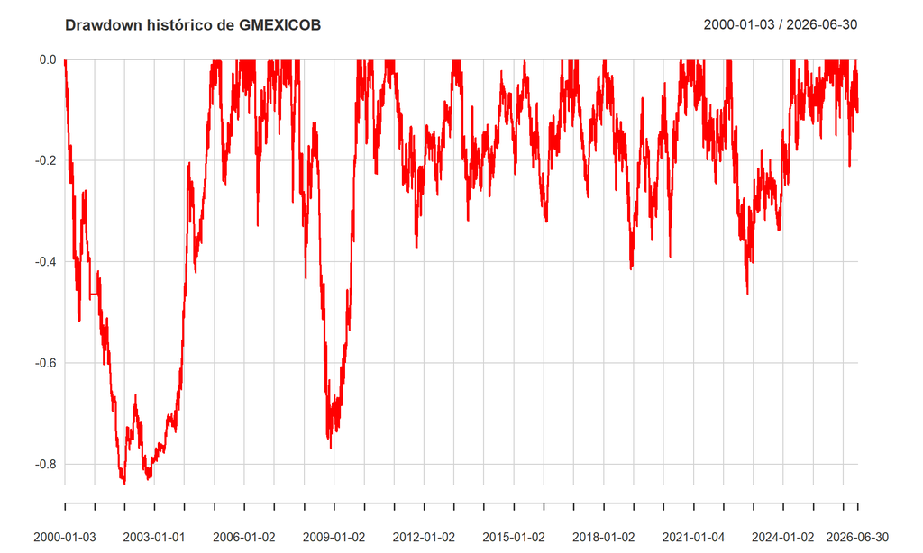

```r
chart.Drawdown(
  simple_rend,
  main = 'Drawdown histórico de GMEXICOB',
  ylab = 'Drawdown',
  col = 'red'
)
```

El resultado de `maxDrawdown` es aproximadamente 0.84008, equivalente a una pérdida máxima de aproximadamente 84.01%. La función presenta la magnitud como un número positivo, mientras que la fórmula incluida en el documento y la columna *Depth* de la tabla expresan la caída con signo negativo. Ambas formas describen el mismo resultado.

Según la tabla, el episodio comenzó el 18 de enero de 2000, alcanzó su mínimo el 2 de enero de 2002 y recuperó el máximo previo el 21 de diciembre de 2004. La fecha inicial identifica el comienzo del periodo por debajo del máximo, por lo que no debe confundirse automáticamente con la fecha exacta en que se alcanzó ese máximo. La duración reportada fue de 1,286 observaciones, que corresponden a sesiones de la serie y no a días naturales.

Para dimensionar la pérdida, una inversión equivalente a 100 unidades en el máximo previo habría disminuido hasta aproximadamente 15.99 en el punto más bajo, siguiendo la evolución de la serie ajustada. Desde ese mínimo habría necesitado aumentar alrededor de 525.3% para recuperar su nivel inicial, ya que $G = 1/(1-0.8401) - 1 \approx 5.253$. Esto muestra que las pérdidas y las recuperaciones no son simétricas, cuanto mayor es la caída, más exigente resulta el crecimiento necesario para compensarla.

El segundo episodio más profundo alcanzó 76.86% y tuvo su mínimo el 20 de noviembre de 2008, mientras que el de 2022 llegó a 46.47% y no recuperó el máximo previo hasta el 9 de abril de 2024. Estos resultados muestran que el riesgo incluye tanto la magnitud de la pérdida como el tiempo durante el cual el capital permanece por debajo de su valor anterior.

La tabla agrupa cada episodio hasta recuperar su máximo de referencia. Por esta razón, la caída de marzo de 2020 forma parte del episodio iniciado en enero de 2018, cuyo mínimo ocurrió el 26 de noviembre de 2018 y cuyo máximo previo no se recuperó hasta el 28 de julio de 2020; por ello no aparece como una fila independiente entre los cinco mayores drawdowns. Además, el 84.01% es una medida histórica de esta muestra, no un límite para las pérdidas que podrían ocurrir en el futuro.

# 3 Identificación de eventos y explicación de cambios

## 3.1 Investigación de noticias y contexto por periodo

Durante 2000-2002, la caída coincidió con un entorno desfavorable para los metales y con la recesión estadounidense de 2001. La documentación de Southern Peru Copper presentada ante la SEC señala que la disminución de los precios de los metales llevó a Minera México a incumplir condiciones de sus contratos de deuda y determinadas obligaciones de pago durante 2001 y 2002. Esto permite relacionar el descenso con una combinación de menores ingresos esperados y presión financiera, aunque no demuestra que toda la pérdida bursátil respondiera a un solo acontecimiento ([Southern Peru Copper Corporation, 2005](https://www.sec.gov/Archives/edgar/data/1001838/000104746905004703/a2152163zdef14a.htm)).

La recuperación de 2003-2007 ocurrió en un contexto muy distinto. El Banco Mundial documentó que el aumento de los precios de los metales desde 2003 estuvo impulsado por la demanda de China y por las dificultades para ampliar la oferta con rapidez. Para Grupo México, vender cobre a mejores precios podía elevar los ingresos y los márgenes, favoreciendo las expectativas sobre su generación de efectivo. Este contexto es consistente con los fuertes rendimientos observados y con la recuperación del máximo anterior en diciembre de 2004 ([Banco Mundial, 2008](https://www.worldbank.org/content/dam/Worldbank/GEP/GEParchives/GEP2008/42097optmzd0REVISED0GEP020081PUBLIC1.pdf)).

El periodo 2007-2009 permite observar tanto el deterioro como la recuperación de esas expectativas. La crisis financiera internacional redujo la disponibilidad de crédito y debilitó la actividad industrial, mientras que los precios del cobre y de otros metales cayeron fuertemente durante la segunda mitad de 2008. Estas condiciones afectaban los ingresos esperados de una empresa minera y elevaban el rendimiento que los inversionistas exigían para mantener sus acciones. Durante 2009, la recuperación de las materias primas, las mejores condiciones financieras y la recuperación de Asia contribuyeron a cambiar ese panorama. La acción recuperó su máximo previo en octubre de 2009, aun cuando la economía mexicana seguía mostrando las consecuencias de la recesión ([Fondo Monetario Internacional, 2009](https://www.imf.org/-/media/websites/imf/imported-flagship-issues/external/pubs/ft/weo/2009/01/pdf/_textpdf.pdf); [Helbling, 2009](https://www.imf.org/en/news/articles/2015/09/28/04/53/sores123009a)).

En 2011, las tensiones de deuda soberana y del sistema financiero europeo, junto con la debilidad de la recuperación internacional, deterioraron la confianza. Interpretamos que este entorno pudo afectar a GMEXICOB mediante una menor demanda esperada de metales y una mayor aversión al riesgo. Así, aunque el problema se originara fuera de México, podía modificar la valoración de una empresa expuesta al ciclo industrial mundial ([Fondo Monetario Internacional, 2011](https://www.imf.org/external/pubs/ft/reo/2011/eur/eng/pdf/ereo1011.pdf)).

Durante 2018, las tensiones comerciales entre Estados Unidos y China aumentaron la incertidumbre sobre la demanda industrial. En su reporte del tercer trimestre, Grupo México mostró que el precio de referencia COMEX del cobre pasó de 3.09 dólares por libra en el segundo trimestre a 2.73 en el tercero, mientras que el EBITDA minero trimestral disminuyó 7.9% frente al mismo periodo del año anterior. El EBITDA (utilidad antes de intereses, impuestos, depreciación y amortización) aproxima la generación de efectivo de la operación, y el precio COMEX es la cotización de referencia del cobre en la bolsa de futuros de Nueva York, del mismo modo que el precio LME, mencionado más adelante, es la referencia de la Bolsa de Metales de Londres. Estos datos ayudan a conectar el deterioro del mercado del cobre con las expectativas de rentabilidad, incluso cuando algunos resultados acumulados todavía presentaban crecimiento ([Grupo México, 2018](https://www.gmexico.com/GMDocs/ReportesFinancieros/Esp/2018/RF_ES_2018_3T.pdf)).

En 2020, la pandemia alteró las expectativas de producción, consumo y transporte, lo que ayuda a explicar la caída inicial. Sin embargo, el mercado de metales comenzó a recuperarse durante ese mismo año, apoyado por la reactivación de la demanda, especialmente en China, y por restricciones de oferta. Posteriormente, Grupo México reportó que el precio promedio de referencia del cobre aumentó 51.4% en 2021 y que sus ventas consolidadas crecieron 35.5%. Estos resultados corroboran la mejora del entorno sectorial, aunque fueron publicados después de finalizar 2021 y no deben presentarse como una noticia conocida durante toda la recuperación ([Banco Mundial, 2020](https://thedocs.worldbank.org/en/doc/f448acf308cc7ba2de536ac5b438b93c-0350012020/original/CMO-October-2020.pdf); [Grupo México, 2022a](https://www.gmexico.com/GMDocs/ReportesFinancieros/ING/2021/RF_EN_2021_4Q.pdf)).

En 2022 coincidieron una inflación elevada, el endurecimiento monetario y preocupaciones sobre el crecimiento mundial. La Reserva Federal elevó su tasa objetivo a un intervalo de 3.00%-3.25% en septiembre, señalando también las presiones derivadas de la guerra en Ucrania. A estos factores se sumaron dificultades operativas de Grupo México, que reportó una reducción de 9.6% en la producción acumulada de cobre a septiembre y afectaciones por bloqueos en Cuajone. Consideramos que la combinación de menores perspectivas de demanda, mayores tasas y restricciones productivas es consistente con el drawdown observado. El reporte empresarial se publicó el 27 de octubre, después del mínimo del día 24, por lo que sirve como confirmación posterior de las condiciones del periodo, no como detonante de ese mínimo ([Reserva Federal, 2022](https://www.federalreserve.gov/newsevents/pressreleases/monetary20220921a.htm); [Grupo México, 2022b](https://www.gmexico.com/GMDocs/Home/Esp/Reporte_3er_Trimestre_2022.pdf)).

## 3.2 Explicación de eventos y su relación con los movimientos del precio

Los acontecimientos anteriores pueden afectar el precio porque modifican las expectativas sobre los flujos futuros de la empresa y el riesgo de recibirlos. Cuando aumenta el precio esperado del cobre, los inversionistas pueden anticipar mayores ingresos y utilidades, mientras que una reducción de la demanda industrial produce el efecto contrario. Debido a que la minería requiere instalaciones y costos que no se ajustan inmediatamente al volumen producido, una variación en ingresos puede generar un cambio importante en los márgenes.

También influye el rendimiento exigido por los inversionistas. Durante una crisis o un periodo de tasas elevadas, pueden requerir una compensación mayor para mantener acciones, lo que reduce el valor presente de los flujos esperados. Por ello, la cotización puede caer incluso cuando la empresa continúa operando y todavía reporta utilidades.

En nuestra interpretación, las crisis internacionales representan riesgos sistemáticos porque afectan a numerosos activos, mientras que los bloqueos de una mina o una propuesta de adquisición introducen riesgos específicos de la empresa. Ambos pueden coincidir y reforzarse, como sucede cuando una operación enfrenta menores volúmenes precisamente mientras se deterioran los precios del metal.

La reacción depende, además, de qué tan diferente sea la información respecto de lo que el mercado esperaba. Un buen resultado puede provocar poco movimiento si ya estaba anticipado, mientras que una noticia inesperada puede generar un ajuste brusco. Por esta razón, las relaciones que planteamos son explicaciones fundamentadas y compatibles con los datos, pero no una demostración de cuánto aportó cada evento al rendimiento. Para aislar ese efecto necesitaríamos comparar ventanas específicas y controlar otros movimientos del mercado.

# 4 Relación con el entorno económico

## 4.1 Gráfica combinada: rendimiento anual del activo vs. crecimiento del PIB

Comparamos los rendimientos anuales de GMEXICOB, calculados con precios ajustados, con la tasa de crecimiento anual del PIB real de México obtenida del Banco Mundial mediante el indicador `NY.GDP.MKTP.KD.ZG`. La comparación abarca 2000-2025, puesto que la serie bursátil termina en junio de 2026 y ese rendimiento parcial no sería directamente comparable con un crecimiento anual completo del PIB ([Banco Mundial, s. f.](https://data.worldbank.org/indicator/NY.GDP.MKTP.KD.ZG?locations=MX)).

Para los años completos, el rendimiento compara el último precio disponible de un año con el cierre del anterior. El dato de 2000 requiere una precisión, dado que la muestra empieza el 3 de enero, su rendimiento se calcula desde esa primera observación y no desde el cierre de 1999.

$$R_{a} =
\left(\frac{P_{a}^{cierre}}{P_{a-1}^{cierre}} - 1\right)\times
100$$

donde $P_{a}^{cierre}$ es el último precio ajustado disponible del año $a$. A diferencia de las fórmulas diarias, aquí el subíndice indica años y no sesiones, y el resultado se expresa en porcentaje para compararlo con el crecimiento del PIB.

```r
# Para el rendimiento anual

rend_anual <- yearlyReturn(
  price,
  type = 'arithmetic'
)

rend_anual <- data.frame(
  anio = as.numeric(format(index(rend_anual), "%Y")),
  rendimiento = as.numeric(rend_anual) * 100
)

head(rend_anual)
```

```
##   anio rendimiento
## 1 2000   -33.32589
## 2 2001   -69.98755
## 3 2002    27.77777
## 4 2003   154.03820
## 5 2004    95.00528
## 6 2005    38.63840
```

```r
# Para el PIB

pib <- WDI(
  country = 'MX',
  indicator = 'NY.GDP.MKTP.KD.ZG',
  start = 2000,
  end = 2025
)

pib <- data.frame(
  anio = pib$year,
  crecimiento_pib = pib$NY.GDP.MKTP.KD.ZG
)

head(pib)
```

```
##   anio crecimiento_pib
## 1 2025       0.5616835
## 2 2024       1.3505763
## 3 2023       3.1067964
## 4 2022       3.7097571
## 5 2021       6.0484835
## 6 2020      -8.3540346
```

```r
datos <- merge(
  rend_anual,
  pib,
  by = "anio"
)

datos <- datos[order(datos$anio), ]

head(datos)
```

```
##   anio rendimiento crecimiento_pib
## 1 2000   -33.32589       5.0292840
## 2 2001   -69.98755      -0.4508453
## 3 2002    27.77777      -0.2365880
## 4 2003   154.03820       1.1855449
## 5 2004    95.00528       3.5654410
## 6 2005    38.63840       2.1132471
```

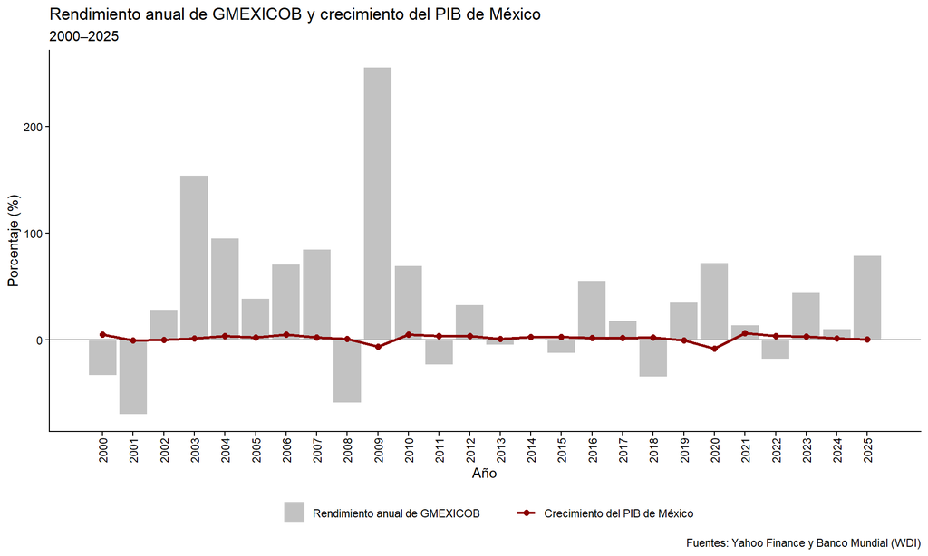

```r
ggplot(datos, aes(x = anio)) +

  geom_hline(yintercept = 0, color = "gray40") +

  geom_col(
    aes(y = rendimiento, fill = "Rendimiento anual de GMEXICOB"),
    alpha = 0.8
  ) +

  geom_line(
    aes(y = crecimiento_pib, color = "Crecimiento del PIB de México"),
    linewidth = 1
  ) +

  geom_point(
    aes(y = crecimiento_pib, color = "Crecimiento del PIB de México"),
    size = 2
  ) +

  scale_fill_manual(
    values = c("Rendimiento anual de GMEXICOB" = "gray70")
  ) +

  scale_color_manual(
    values = c("Crecimiento del PIB de México" = "dark red")
  ) +

  scale_x_continuous(breaks = datos$anio) +

  labs(
    title = "Rendimiento anual de GMEXICOB y crecimiento del PIB de México",
    subtitle = "2000–2025",
    x = "Año",
    y = "Porcentaje (%)",
    fill = "",
    color = "",
    caption = "Fuentes: Yahoo Finance y Banco Mundial (WDI)"
  ) +

  theme_classic() +

  theme(
    axis.text.x = element_text(angle = 90, vjust = 0.5),
    legend.position = "bottom"
  )
```

Aunque ambas variables se expresan en porcentajes, representan conceptos diferentes. El rendimiento bursátil mide la variación de una inversión en un periodo, mientras que el crecimiento del PIB real mide el cambio en el volumen de producción de la economía. Por ello, la gráfica debe leerse comparando la dirección y el momento de los movimientos, no su tamaño.

La primera característica que destaca es la diferencia de escala. Los rendimientos anuales de GMEXICOB van de −69.99% (2001) a 255.22% (2009), con una desviación estándar cercana a 68 puntos porcentuales, mientras que el crecimiento del PIB se mueve entre −8.35% (2020) y 6.05% (2021), con una desviación estándar de aproximadamente 3 puntos. Por esa razón la línea del PIB parece casi plana al compartir el eje con las barras, aunque sus variaciones sean relevantes para la economía.

En cuanto a la dirección, ambas series tuvieron el mismo signo en 15 de los 26 años. Sin embargo, las discrepancias se concentran justamente en los años de crisis y recuperación. El PIB fue negativo en cinco años (2001, 2002, 2009, 2019 y 2020) y la acción solo cayó en uno de ellos, 2001. A la inversa, la acción registró rendimientos negativos en ocho años (2000, 2001, 2008, 2011, 2013, 2015, 2018 y 2022) y en siete de ellos la economía mexicana creció.

La gráfica también sugiere un desfase temporal. En 2008 la acción cayó 58.84% mientras el PIB todavía crecía 0.94%, y en 2009 la acción subió 255.22% mientras el PIB se contraía 6.30%. Es decir, el mercado registró la crisis y la recuperación aproximadamente un año antes de que se reflejaran en la producción anual del país. Este patrón es compatible con la idea de que el precio de la acción responde a expectativas, y lo evaluamos numéricamente más adelante.

## 4.2 Análisis de la relación con el ciclo económico

La gráfica muestra algunas coincidencias, pero no una relación constante entre GMEXICOB y el PIB mexicano. En 2001, por ejemplo, la acción registró un rendimiento de aproximadamente −69.99%, mientras que el PIB disminuyó alrededor de 0.45%. Ambas variables se movieron en la misma dirección, aunque con intensidades muy distintas. Esto indica que el deterioro del entorno puede coincidir con pérdidas bursátiles mucho mayores que la contracción de la economía.

En otros años observamos diferencias claras. Durante 2000, el PIB creció aproximadamente 5.03%, mientras que el rendimiento del activo dentro de la muestra fue de −33.33%. En 2003, la acción aumentó 154.04%, frente a un crecimiento del PIB de alrededor de 1.19%. Estas diferencias muestran que el desempeño de Grupo México no depende exclusivamente de la actividad económica nacional.

El caso de 2009 es especialmente ilustrativo, porque la acción obtuvo un rendimiento de 255.22% al mismo tiempo que el PIB mexicano se contrajo 6.30%. Algo semejante ocurrió en 2020, cuando el PIB disminuyó 8.35%, mientras que el rendimiento anual de la acción fue de 71.75%. Esto no significa que la pandemia beneficiara de manera uniforme al activo, pues entre el 2 de enero y el 23 de marzo de 2020 el precio cayó alrededor de 30.5%, sino que la recuperación posterior superó la pérdida inicial al comparar los extremos del año.

La diferencia tiene sentido porque el precio de una acción incorpora expectativas, mientras que el PIB anual resume la producción realizada durante todo el periodo. El mercado puede comenzar a descontar una recuperación antes de que esta se refleje plenamente en la actividad económica. Además, Grupo México participa en mercados internacionales y está expuesto al precio mundial del cobre, por lo que cambios en China, Estados Unidos o la oferta minera pueden ser más relevantes para su valoración que una variación aislada del PIB mexicano.

En 2025 vuelve a observarse esta separación, con un rendimiento bursátil de 78.80% y un crecimiento del PIB de aproximadamente 0.56% en la información utilizada.

Para complementar la lectura visual calculamos el coeficiente de correlación de Pearson entre ambas series anuales,

$$\rho=\frac{\sum_{a}\left(R_a-\bar{R}\right)\left(g_a-\bar{g}\right)}
{\sqrt{\sum_{a}\left(R_a-\bar{R}\right)^2}\sqrt{\sum_{a}\left(g_a-\bar{g}\right)^2}},$$

donde $R_a$ es el rendimiento anual de GMEXICOB y $g_a$ el crecimiento del PIB en el año $a$. El coeficiente toma valores entre −1 y 1: valores cercanos a 1 indican que ambas variables suben y bajan juntas, cercanos a −1 que se mueven en sentidos opuestos, y cercanos a 0 que no existe una relación lineal clara.

```r
cor.test(datos$rendimiento, datos$crecimiento_pib)
```

```
##
##  Pearson's product-moment correlation
##
## data:  datos$rendimiento and datos$crecimiento_pib
## t = -2.1277, df = 24, p-value = 0.04383
## alternative hypothesis: true correlation is not equal to 0
## 95 percent confidence interval:
##  -0.6806849 -0.0130269
## sample estimates:
##        cor
## -0.3983687
```

La correlación de Pearson es de aproximadamente −0.40, una relación negativa de magnitud moderada: en la muestra 2000-2025 los años de mayor rendimiento bursátil tendieron a coincidir con un crecimiento económico menor, y no mayor. Además, con solo 26 observaciones el valor p de la prueba de Pearson es de aproximadamente 0.044, apenas por debajo del umbral convencional de 5%, y su intervalo de confianza de 95% (de −0.68 a −0.01) casi incluye el cero, por lo que la evidencia estadística es débil.

Para saber qué tanto depende el resultado de los años extremos, repetimos el cálculo excluyendo 2009 y 2020, y comparamos también el rendimiento de cada año con el crecimiento del PIB del año siguiente.

```r
sin_2009 <- datos[datos$anio != 2009, ]
sin_2020 <- datos[datos$anio != 2020, ]
sin_ambos <- datos[!datos$anio %in% c(2009, 2020), ]

c(
  todos = cor(datos$rendimiento, datos$crecimiento_pib),
  sin_2009 = cor(sin_2009$rendimiento, sin_2009$crecimiento_pib),
  sin_2020 = cor(sin_2020$rendimiento, sin_2020$crecimiento_pib),
  sin_2009_ni_2020 = cor(sin_ambos$rendimiento, sin_ambos$crecimiento_pib)
)
```

```
##            todos         sin_2009         sin_2020 sin_2009_ni_2020
##      -0.39836867      -0.09484924      -0.43043282       0.07522374
```

```r
# Rendimiento del año a frente al crecimiento del PIB del año a + 1
pib_siguiente <- c(datos$crecimiento_pib[-1], NA)

cor(datos$rendimiento, pib_siguiente, use = "complete.obs")
```

```
## [1] 0.4109923
```

El análisis de sensibilidad muestra que la correlación negativa depende casi por completo de 2009. Sin ese año, la correlación de Pearson pasa a −0.10; sin 2020 se mantiene en −0.43; y sin ambos años se vuelve ligeramente positiva (0.08). Por lo tanto, no conviene interpretar el −0.40 como una tendencia general de la acción a moverse en contra de la economía, sino como el efecto de un año excepcional en el que la acción se recuperó con fuerza mientras el PIB se contraía.

En cambio, al comparar el rendimiento de cada año con el crecimiento del PIB del año siguiente, la correlación se vuelve positiva, con un valor de alrededor de 0.41. Este resultado es consistente con el desfase observado en 2008-2009: los años de buen rendimiento bursátil tendieron a anteceder años de mayor crecimiento económico. Lo tomamos como una evidencia descriptiva y no como una prueba de capacidad predictiva, puesto que se basa en solo 25 pares de observaciones.

A partir de estos resultados, consideramos que GMEXICOB presenta sensibilidad al ciclo industrial y de materias primas, pero no reproduce de manera contemporánea el ciclo económico de México; su relación con la economía nacional parece darse más bien de forma anticipada. Debemos recordar, además, que la correlación no implica causalidad.

# 5 Análisis de los periodos más recientes

## 5.1 Eventos relevantes del último año

Para mantener coherencia con el corte de las gráficas, analizamos el periodo del 1 de julio de 2025 al 30 de junio de 2026.

En julio de 2025, los anuncios estadounidenses sobre aranceles al cobre introdujeron incertidumbre en ese mercado. La disposición del 30 de julio estableció un arancel de 50% sobre determinados productos semielaborados y derivados intensivos en cobre, pero excluyó minerales, concentrados y cobre refinado, entre otros productos. Esta distinción es relevante porque no corresponde afirmar que todas las exportaciones de cobre de Grupo México quedaron sujetas al mismo gravamen. Para el activo, el efecto potencial provenía de cambios en las expectativas comerciales y en los precios relativos del metal ([The White House, 2025](https://www.whitehouse.gov/fact-sheets/2025/07/fact-sheet-president-donald-j-trump-takes-action-to-address-the-threat-to-national-security-from-imports-of-copper/)).

Un acontecimiento empresarial particularmente claro fue la propuesta de adquisición de Banamex anunciada por Grupo México el 3 de octubre de 2025. El 6 de octubre, la prensa financiera registró una caída de 15.43% en sus acciones; en nuestra serie de precios ajustados de Yahoo Finance, el rendimiento de cierre a cierre de ese día fue de −14.99%, la diferencia puede atribuirse al precio de referencia utilizado por cada fuente. Posteriormente, la empresa aclaró que el crédito máximo que requeriría la operación sería menor a 2 mil millones de dólares, por lo que no esperaba incrementar significativamente su deuda, y que mantendría sus proyectos de inversión. Interpretamos que la reacción estuvo relacionada con dudas sobre la asignación de capital y la incorporación de un negocio distinto de sus principales operaciones ([López, 2025](https://www.bloomberglinea.com/latinoamerica/mexico/grupo-mexico-defiende-propuesta-de-compra-de-banamex-tras-desplome-de-la-accion/); [Grupo México, 2025](https://www.bmv.com.mx/docs-pub/eventemi/eventemi_1497656_1.pdf)).

En cuanto a resultados, el reporte del cuarto trimestre de 2025, publicado en enero de 2026, presentó un crecimiento anual de ventas de 12.4%. El precio de referencia LME del cobre aumentó 8.7% durante 2025, aunque la producción del metal disminuyó 1.5%. Este contraste muestra que los ingresos pueden mejorar aun con menor producción cuando los precios de venta y los subproductos compensan esa disminución ([Grupo México, 2026a](https://www.gmexico.com/GMDocs/ReportesFinancieros/Esp/2025/RF_ES_2025_4T.pdf)).

Los resultados del primer trimestre de 2026 también mostraron una mejora. El comunicado fechado el 28 de abril reportó ventas consolidadas de aproximadamente US$5,565 millones, 32.7% superiores a las del mismo trimestre de 2025, y un incremento de 49.6% en EBITDA. La producción de cobre disminuyó 2.8%, mientras que su precio de referencia LME aumentó 37.5% interanual. Nuevamente observamos que el entorno de precios tuvo un papel relevante en el desempeño del negocio ([Grupo México, 2026b, comunicado reproducido por MarketScreener](https://es.marketscreener.com/noticias/grupo-mexico-b-de-c-primer-trimestre-report-rf-es-2026-1t-ce7f58dadc8af324)).

El 27 de abril de 2026, Grupo México anunció un acuerdo para combinar activos de generación eléctrica con Saavi Energía, en una plataforma cuya participación prevista sería de 70% para Grupo México. Al cierre de nuestro análisis, el acuerdo estaba sujeto a autorizaciones, por lo que lo consideramos una expectativa de expansión y diversificación, sin tratarlo como una operación ya concluida ([Grupo México, 2026c](https://www.bmv.com.mx/docs-pub/eventemi/eventemi_1551582_1.pdf)).

Finalmente, la tasa objetivo del Banco de México pasó de 8.00% al inicio de julio de 2025 a 6.50% en junio de 2026. Una reducción de tasas puede favorecer la valoración de las acciones al modificar el rendimiento requerido y su atractivo frente a instrumentos de deuda, aunque este efecto no garantiza una subida y debe analizarse junto con el tipo de cambio y el entorno internacional ([Banco de México, 2025](https://www.banxico.org.mx/publicaciones-y-prensa/anuncios-de-las-decisiones-de-politica-monetaria/%7B7774AEE4-AF2E-9A74-A34C-EDB53F483361%7D.pdf); [Banco de México, 2026](https://www.banxico.org.mx/publicaciones-y-prensa/anuncios-de-las-decisiones-de-politica-monetaria/%7BF6667DDE-E87D-68A3-0EBB-A4DF9048E403%7D.pdf)).

## 5.2 Reflejo de dichos eventos en el precio y los rendimientos

El tramo final de la gráfica muestra una apreciación importante durante 2025 y el primer semestre de 2026, acompañada de correcciones. Consideramos que esta trayectoria es compatible con un entorno favorable de precios de metales y con la mejora de resultados reportada por la empresa. Sin embargo, el avance comenzó antes de la publicación de algunos reportes, por lo que no sería correcto atribuir toda la subida a la fecha en que se divulgaron. Parte de esa información pudo incorporarse gradualmente mediante expectativas sobre el cobre y la operación.

La propuesta por Banamex permite observar un mecanismo diferente, porque introdujo incertidumbre sobre una decisión propia de la empresa. La caída de cerca de 15% del 6 de octubre de 2025 (−14.99% en nuestra serie) ocurrió dentro de un periodo de tendencia general ascendente, en el que la acción acumuló 78.80% en 2025 y aproximadamente 79.2% entre el 1 de julio de 2025 y el 30 de junio de 2026, lo que muestra que un buen rendimiento acumulado no evita pérdidas intensas en una sola sesión.

Los anuncios comerciales y las decisiones de tasas también pudieron modificar las expectativas, aunque con las gráficas disponibles no podemos separar sus efectos ni asignarles un porcentaje específico del rendimiento. Un cambio arancelario puede beneficiar a ciertos productores y afectar a otros, mientras que una reducción de tasas puede coincidir con preocupaciones sobre el crecimiento que compensen su efecto favorable.

Por ello, interpretamos el periodo reciente como la combinación de mejores condiciones para la generación de utilidades y episodios de nueva incertidumbre. La acción respondió a información sobre su negocio y sobre el entorno, sin seguir una trayectoria uniforme ni predecible. Para estudiar con mayor precisión cada reacción sería necesario ampliar las gráficas alrededor de las fechas de los anuncios y comparar el movimiento de GMEXICOB con el del mercado.

# 6 Conclusión

El análisis muestra que GMEXICOB ha generado una apreciación considerable durante la muestra, pero esa trayectoria estuvo acompañada de pérdidas profundas y recuperaciones de distinta duración. El máximo drawdown de 84.01% permite dimensionar un riesgo que no se aprecia con claridad al observar únicamente el precio final, puesto que una inversión puede terminar con un resultado favorable y, aun así, haber enfrentado una pérdida difícil de soportar durante varios años.

Los periodos estudiados también muestran que el precio responde a distintos tipos de información. La debilidad de los metales y la presión financiera a comienzos de los años dos mil, la crisis de 2008, las tensiones comerciales, la pandemia y el endurecimiento monetario de 2022 afectaron las perspectivas de ingresos y el riesgo percibido. El caso de Banamex añade que las decisiones corporativas pueden provocar movimientos relevantes incluso dentro de un entorno favorable para la actividad principal del grupo.

La comparación con el PIB nos permitió comprender que el ciclo económico mexicano aporta contexto, pero no explica por sí solo el comportamiento de la acción. La correlación contemporánea entre ambas series es negativa (−0.40), pero depende casi por completo de 2009, mientras que el rendimiento de cada año se relaciona positivamente con el crecimiento del año siguiente, lo que sugiere que el mercado se anticipa a la economía. Grupo México participa en mercados internacionales y sus inversionistas valoran resultados futuros, por ello la cotización puede recuperarse mientras la economía todavía se contrae o aumentar con fuerza durante un año de bajo crecimiento nacional. Además, el rendimiento anual puede ocultar pérdidas y recuperaciones importantes dentro del mismo periodo.

A partir de este ejercicio, entendemos que analizar el riesgo requiere considerar la magnitud de las variaciones, el tiempo de recuperación y los mecanismos por los que cambia la valoración. Los acontecimientos históricos ayudan a construir explicaciones y escenarios, aunque no permiten anticipar con certeza la siguiente crisis o la reacción del mercado. Para un inversionista, esta incertidumbre implica que conocer bien la empresa mejora la calidad de sus decisiones, pero no elimina la exposición a noticias, choques externos y cambios de expectativas que están fuera de su control.

# 7 Referencias

Banco de México. (2025, 26 de junio). *[Anuncio de política monetaria](https://www.banxico.org.mx/publicaciones-y-prensa/anuncios-de-las-decisiones-de-politica-monetaria/%7B7774AEE4-AF2E-9A74-A34C-EDB53F483361%7D.pdf)*.

Banco de México. (2026, 25 de junio). *[Anuncio de política monetaria](https://www.banxico.org.mx/publicaciones-y-prensa/anuncios-de-las-decisiones-de-politica-monetaria/%7BF6667DDE-E87D-68A3-0EBB-A4DF9048E403%7D.pdf)*.

Banco Mundial. (2008). *[Global economic prospects 2008: Technology diffusion in the developing world](https://www.worldbank.org/content/dam/Worldbank/GEP/GEParchives/GEP2008/42097optmzd0REVISED0GEP020081PUBLIC1.pdf)*.

Banco Mundial. (2020, octubre). *[Commodity markets outlook](https://thedocs.worldbank.org/en/doc/f448acf308cc7ba2de536ac5b438b93c-0350012020/original/CMO-October-2020.pdf)*.

Banco Mundial. (s. f.). *[GDP growth (annual %) — Mexico](https://data.worldbank.org/indicator/NY.GDP.MKTP.KD.ZG?locations=MX)* [Conjunto de datos]. World Development Indicators. Recuperado el 22 de septiembre de 2026.

Fondo Monetario Internacional. (2009). *[World economic outlook, April 2009: Crisis and recovery](https://www.imf.org/-/media/websites/imf/imported-flagship-issues/external/pubs/ft/weo/2009/01/pdf/_textpdf.pdf)*.

Fondo Monetario Internacional. (2011). *[Regional economic outlook: Europe. Navigating stormy waters](https://www.imf.org/external/pubs/ft/reo/2011/eur/eng/pdf/ereo1011.pdf)*.

Grupo México. (2018, 24 de octubre). *[Resultados. Tercer trimestre 2018](https://www.gmexico.com/GMDocs/ReportesFinancieros/Esp/2018/RF_ES_2018_3T.pdf)*.

Grupo México. (2022a, 1 de febrero). *[Results. Fourth quarter 2021](https://www.gmexico.com/GMDocs/ReportesFinancieros/ING/2021/RF_EN_2021_4Q.pdf)*.

Grupo México. (2022b, 27 de octubre). *[Resultados. Tercer trimestre 2022](https://www.gmexico.com/GMDocs/Home/Esp/Reporte_3er_Trimestre_2022.pdf)*.

Grupo México. (2025, 7 de octubre). *[Grupo México no incrementaría de manera significativa su deuda en caso de que se acepte su oferta por Banamex](https://www.bmv.com.mx/docs-pub/eventemi/eventemi_1497656_1.pdf)* [Comunicado]. Bolsa Mexicana de Valores.

Grupo México. (2026a, 27 de enero). *[Resultados. Cuarto trimestre 2025](https://www.gmexico.com/GMDocs/ReportesFinancieros/Esp/2025/RF_ES_2025_4T.pdf)*.

Grupo México. (2026b, 28 de abril). *[Resultados. Primer trimestre 2026](https://es.marketscreener.com/noticias/grupo-mexico-b-de-c-primer-trimestre-report-rf-es-2026-1t-ce7f58dadc8af324)* [Comunicado reproducido por MarketScreener].

Grupo México. (2026c, 27 de abril). *[Grupo México anuncia la combinación estratégica de sus activos de generación de energía con Saavi Energía](https://www.bmv.com.mx/docs-pub/eventemi/eventemi_1551582_1.pdf)* [Comunicado]. Bolsa Mexicana de Valores.

Helbling, T. (2009, 30 de diciembre). *[Commodity prices buoyant in year of crisis, recovery](https://www.imf.org/en/news/articles/2015/09/28/04/53/sores123009a)*. Fondo Monetario Internacional.

López, I. (2025, 7 de octubre). *[Grupo México defiende propuesta de compra de Banamex tras desplome de la acción](https://www.bloomberglinea.com/latinoamerica/mexico/grupo-mexico-defiende-propuesta-de-compra-de-banamex-tras-desplome-de-la-accion/)*. Bloomberg Línea.

Reserva Federal. (2022, 21 de septiembre). *[Federal Reserve issues FOMC statement](https://www.federalreserve.gov/newsevents/pressreleases/monetary20220921a.htm)*.

Southern Peru Copper Corporation. (2005). *[Definitive proxy statement (Schedule 14A)](https://www.sec.gov/Archives/edgar/data/1001838/000104746905004703/a2152163zdef14a.htm)*. U.S. Securities and Exchange Commission.

The White House. (2025, 30 de julio). *[Fact sheet: President Donald J. Trump takes action to address the threat to national security from imports of copper](https://www.whitehouse.gov/fact-sheets/2025/07/fact-sheet-president-donald-j-trump-takes-action-to-address-the-threat-to-national-security-from-imports-of-copper/)*.

Yahoo. (s. f.). *[What is the adjusted close?](https://help.yahoo.com/kb/SLN28256.html)*. Yahoo Help.

Yahoo Finance. (s. f.). *[Grupo México, S.A.B. de C.V. (GMEXICOB.MX): Historical data](https://finance.yahoo.com/quote/GMEXICOB.MX/history/)* [Conjunto de datos]. Serie utilizada en el documento para el periodo del 3 de enero de 2000 al 30 de junio de 2026.